# colourlog: generate plots of colourlogs from core photographs

Ilja J. Kocken

Utrecht University  
i.j.kocken@uu.nl

Here we try to generate an image of the colourlog that you have generated based on core photographs!

# assumed pre-work

This script assumes that you have already successfully applied the DeCrack routine in Matlab, which gets colour information from the core photograph after removing cracks [@cite:Zeeden2015].

In short, the procedure is to first clean up the core photographs manually (in Photoshop or similar). 1. download the core photographs from the [janus database](http://iodp.tamu.edu/janusweb/imaging/photo.shtml) 2. split them into sections that you manually align, so that the image distortion is minimized 3. clean up each section, by colouring bioturbation signs and water sample foam black 4. run the DeCrack matlab script in matlab

# load necessary libraries

```r
library(tidyverse)
library(readxl)
library(plotly)
library(ggtextures)
library(patchwork)
```

# read in the decracked data

The output of the matlab script is stored in .dat files where 1 is unaltered data 2 is after removed cracks data

## create a list of column names

Column names are described in table 1 in [@cite:Zeeden2015].

```r
names <- c("distance_from_core_top1",
           "mean_greyscale_values1",
           "standard_deviation_of_greyscale_values1",
           "median_of_greyscale_values1",
           "mean_red_values1",
           "standard_deviation_of_red_values1",
           "median_of_red_values1",
           "mean_green_values1",
           "standard_deviation_of_green_values1",
           "median_of_green_values1",
           "mean_blue_values1",
           "standard_deviation_of_blue_values1",
           "median_of_blue_values1",
           "distance_from_core_top2",
           "mean_greyscale_values2",
           "standard_deviation_of_greyscale_values2",
           "median_of_greyscale_values2",
           "mean_red_values2",
           "standard_deviation_of_red_values2",
           "median_of_red_values2",
           "mean_green_values2",
           "standard_deviation_of_green_values2",
           "median_of_green_values2",
           "mean_blue_values2",
           "standard_deviation_of_blue_values2",
           "median_of_blue_values2")
```

## read in a single output file to see if it works with these column names

```r
dat1 <- read_delim("dat/decrackoutput/959A30X-1.dat",
                   delim = ' ',
                   trim_ws = TRUE,
                   col_names = names)
```

```
# Rows: 150 Columns: 26
# ── Column specification ──────────────────────────────────────────────────────
# Delimiter: " "
# dbl (26): distance_from_core_top1, mean_greyscale_values1, standard_deviatio...
#
# ℹ Use `spec()` to retrieve the full column specification for this data.
# ℹ Specify the column types or set `show_col_types = FALSE` to quiet this message.
```

```r
glimpse(dat1)
```

```
# Rows: 150
# Columns: 26
# $ distance_from_core_top1                 <dbl> 0.5, 1.5, 2.5, 3.5, 4.5, 5.5, …
# $ mean_greyscale_values1                  <dbl> 40.01014, 39.25964, 43.37678, …
# $ standard_deviation_of_greyscale_values1 <dbl> 61.63746, 65.34229, 57.38894, …
# $ median_of_greyscale_values1             <dbl> 0.0, 0.0, 18.0, 53.0, 55.0, 48…
# $ mean_red_values1                        <dbl> 13.96197, 13.56947, 15.21095, …
# $ standard_deviation_of_red_values1       <dbl> 21.34318, 22.61043, 20.03387, …
# $ median_of_red_values1                   <dbl> 0.0, 0.0, 7.0, 20.0, 20.0, 18.…
# $ mean_green_values1                      <dbl> 13.26065, 13.05020, 13.13540, …
# $ standard_deviation_of_green_values1     <dbl> 21.00893, 22.70261, 19.46839, …
# $ median_of_green_values1                 <dbl> 0.0, 0.0, 3.0, 15.0, 15.0, 13.…
# $ mean_blue_values1                       <dbl> 12.78753, 12.63996, 15.03043, …
# $ standard_deviation_of_blue_values1      <dbl> 19.43377, 20.23959, 18.22221, …
# $ median_of_blue_values1                  <dbl> 0, 0, 8, 18, 19, 17, 22, 24, 2…
# $ distance_from_core_top2                 <dbl> 0.5, 1.5, 2.5, 3.5, 4.5, 5.5, …
# $ mean_greyscale_values2                  <dbl> 133.6398, 142.6307, 127.5649, …
# $ standard_deviation_of_greyscale_values2 <dbl> 43.45625, 58.47073, 49.49661, …
# $ median_of_greyscale_values2             <dbl> 130.0, 130.0, 114.0, 116.0, 10…
# $ mean_red_values2                        <dbl> 46.34674, 49.23542, 44.50100, …
# $ standard_deviation_of_red_values2       <dbl> 14.98561, 20.49059, 17.24443, …
# $ median_of_red_values2                   <dbl> 45.0, 45.0, 40.0, 41.0, 37.0, …
# $ mean_green_values2                      <dbl> 45.15134, 48.60043, 41.56687, …
# $ standard_deviation_of_green_values2     <dbl> 15.15645, 21.61945, 17.96692, …
# $ median_of_green_values2                 <dbl> 44, 44, 37, 37, 34, 35, 35, 33…
# $ mean_blue_values2                       <dbl> 42.14176, 44.79482, 41.49701, …
# $ standard_deviation_of_blue_values2      <dbl> 13.73924, 16.90331, 14.81062, …
# $ median_of_blue_values2                  <dbl> 41, 41, 38, 38, 34, 35, 35, 35…
```

That seems to work!

## List all the datafiles

```r
path <- "dat/decrackoutput"

files <- list.files(path,
                    pattern = '.dat$',
                    full.names = FALSE)
```

## Get metadata from filename

We create a [tibble](https://tibble.tidyverse.org/)/dataframe with one file per line, and extract all the relevant metadata from the filename into separate columns.

```r
main <- tibble(file=files) |>
  mutate(site = str_extract(file, "^\\d+") |>
           parse_integer(),
         hole = str_extract(file, "[A-D]"),
         type = str_extract(file, "X"),
         core = str_extract(file, "\\d+X-") |>
           str_replace("X-", "") |>
           parse_integer(),
         section = str_extract(file, "-\\d+") |>
           str_replace("-", "") |>
           parse_integer())
main
```

```
# # A tibble: 8 × 6
#   file           site hole  type   core section
#   <chr>         <int> <chr> <chr> <int>   <int>
# 1 959A30X-1.dat   959 A     X        30       1
# 2 959A30X-2.dat   959 A     X        30       2
# 3 959A30X-3.dat   959 A     X        30       3
# 4 959A30X-4.dat   959 A     X        30       4
# 5 959A30X-5.dat   959 A     X        30       5
# 6 959A30X-6.dat   959 A     X        30       6
# 7 959A30X-7.dat   959 A     X        30       7
# 8 959A30X-8.dat   959 A     X        30       8
```

## Read colour data

This now uses the above tibble and reads in the file like we did for `dat1` above. Except now each row is a [nested tibble](https://tidyr.tidyverse.org/articles/nest.html).

```r
main <- main |>
  mutate(data = map(file,
                   ~ read_delim(paste0(path, '/', .x),
                                delim = " ",
                                trim_ws = TRUE,
                                col_names = names)))
```

[output not shown]

We unnest the data so that we go back to a flat tibble, where all the files are listed below each other. Note that the rows that were unique to each file are now repeated as many times as there are data in the file.

```r
flat <- main |> unnest(cols=data)
flat
```

```
# # A tibble: 977 × 32
#    file   site hole  type   core section dista…¹ mean_…² stand…³ media…⁴ mean_…⁵
#    <chr> <int> <chr> <chr> <int>   <int>   <dbl>   <dbl>   <dbl>   <dbl>   <dbl>
#  1 959A…   959 A     X        30       1     0.5    40.0    61.6       0    14.0
#  2 959A…   959 A     X        30       1     1.5    39.3    65.3       0    13.6
#  3 959A…   959 A     X        30       1     2.5    43.4    57.4      18    15.2
#  4 959A…   959 A     X        30       1     3.5    66.3    60.9      53    23.8
#  5 959A…   959 A     X        30       1     4.5    63.6    55.6      55    22.8
#  6 959A…   959 A     X        30       1     5.5    59.8    56.7      48    21.4
#  7 959A…   959 A     X        30       1     6.5    71.4    61.9      67    25.9
#  8 959A…   959 A     X        30       1     7.5    76.7    56.5      71    28.1
#  9 959A…   959 A     X        30       1     8.5    68.2    62.0      60    24.8
# 10 959A…   959 A     X        30       1     9.5    45.2    51.2      24    16.4
# # … with 967 more rows, 21 more variables:
# #   standard_deviation_of_red_values1 <dbl>, median_of_red_values1 <dbl>,
# #   mean_green_values1 <dbl>, standard_deviation_of_green_values1 <dbl>,
# #   median_of_green_values1 <dbl>, mean_blue_values1 <dbl>,
# #   standard_deviation_of_blue_values1 <dbl>, median_of_blue_values1 <dbl>,
# #   distance_from_core_top2 <dbl>, mean_greyscale_values2 <dbl>,
# #   standard_deviation_of_greyscale_values2 <dbl>, …
```

Let’s take a quick look at what we have now:

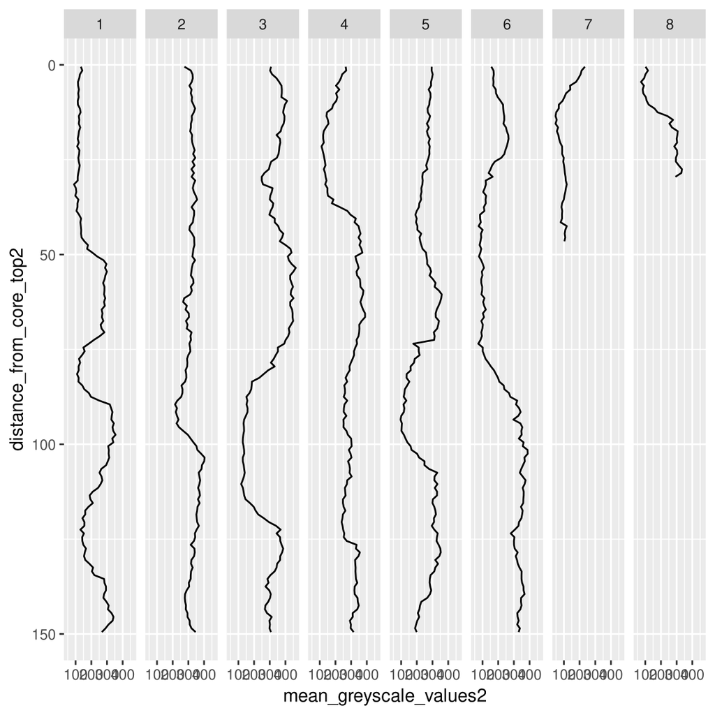

```r
flat |>
  ggplot(aes(x = mean_greyscale_values2, y = distance_from_core_top2)) +
  geom_path() +
  scale_y_reverse() +
  facet_grid(cols = vars(section))
```

Good! We have the colour information for each section!

# load the core images

First we list all the cropped section images, and get their metadata from the filenames.

```r
imgs <- tibble(file = list.files("dat/croppedsections", pattern = "*.png")) |>
  # this is the second time we do this, should probably make it a function
  mutate(site=str_extract(file, "^\\d+") |>
           parse_integer(),
         hole=str_extract(file, "[A-D]"),
         type=str_extract(file, "X"),
         core=str_extract(file, "\\d+X-") |>
           str_replace("X-", "") |>
           parse_integer(),
         section=str_extract(file, "-\\d+") |>
           str_replace("-", "") |>
           parse_integer())
```

Note that there are just a few section images here, so we can easily plot them all, but if you use more than this you should shrink them first before trying to plot them, otherwise your R session might crash! See [my corepics repository](https://github.com/japhir/corepics).

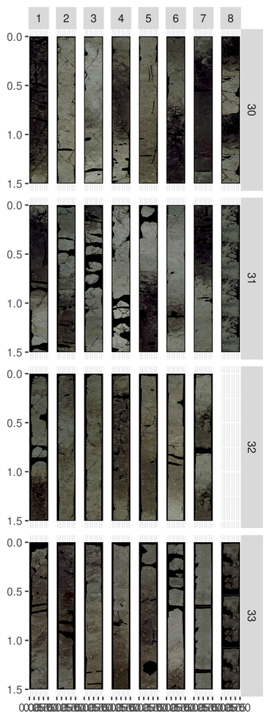

```r
imgs |>
  ## slice(1) |> # try it out for a single image
  ggplot(aes(xmin = 0, xmax = 1, ymin = 0, ymax = 1.50)) +
  # here we turn the filename into the filepath, relative to this project
  geom_textured_rect(aes(image = paste0("dat/croppedsections/", file))) +
  scale_y_reverse() +
  facet_grid(cols = vars(section), rows = vars(core))
```

Currently we do not have the information for the height/depth of these images, however.

# load section depths

We need to now link the colour log data to depth information, and ultimately to age information. So we first read in the metadata, which we downloaded from [Janus database](https://web.iodp.tamu.edu/janusweb/coring_summaries/coresumm.cgi).

```r
coresumm <- read_tsv("dat/coresumm.tsv")
```

```
# Warning: One or more parsing issues, call `problems()` on your data frame for details,
# e.g.:
#   dat <- vroom(...)
#   problems(dat)
```

```
# Rows: 1073 Columns: 10
# ── Column specification ──────────────────────────────────────────────────────
# Delimiter: "\t"
# chr (4): H, T, Sc, Comment
# dbl (6): Leg, Site, Cor, LL(m), CL(m), Top(mbsf)
#
# ℹ Use `spec()` to retrieve the full column specification for this data.
# ℹ Specify the column types or set `show_col_types = FALSE` to quiet this message.
```

```r
coresumm
```

```
# # A tibble: 1,073 × 10
#      Leg  Site H       Cor T     Sc    `LL(m)` `CL(m)` `Top(mbsf)` Comment
#    <dbl> <dbl> <chr> <dbl> <chr> <chr>   <dbl>   <dbl>       <dbl> <chr>
#  1   159   959 A         1 H     1        1.5     1.5         0    <NA>
#  2   159   959 A         1 H     2        1.5     1.5         1.5  <NA>
#  3   159   959 A         1 H     3        1.5     1.5         3    <NA>
#  4   159   959 A         1 H     4        1.5     1.5         4.5  <NA>
#  5   159   959 A         1 H     5        1.5     1.5         6    <NA>
#  6   159   959 A         1 H     6        1.32    1.32        7.5  <NA>
#  7   159   959 A         1 H     CC       0.26    0.26        8.82 6 CM TO PALEO
#  8   159   959 A         2 H     1        1.5     1.5         9.1  <NA>
#  9   159   959 A         2 H     2        1.5     1.5        10.6  <NA>
# 10   159   959 A         2 H     3        1.5     1.5        12.1  <NA>
# # … with 1,063 more rows
```

Now that we have the metadata, we can attach it to the images.

```r
imgs <- imgs |>
  tidylog::left_join(coresumm |>
                       mutate(Sc = ifelse(str_detect(Sc, "CC"), "8", Sc) |>
                                parse_integer()),
                     by = c('site' = 'Site',
                            'hole' = 'H',
                            'core' = 'Cor',
                            'type' = 'T',
                            'section' = 'Sc'))
```

```
# left_join: added 5 columns (Leg, LL(m), CL(m), Top(mbsf), Comment)
```

```
#            > rows only in x       0
```

```
#            > rows only in y  (1,042)
```

```
#            > matched rows        31
```

```
#            >                 =======
```

```
#            > rows total          31
```

and make proper plots of our sections

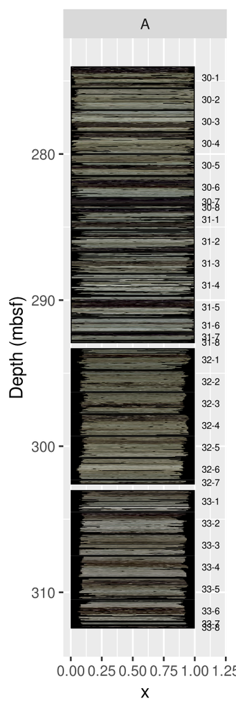

```r
corepics <- imgs |>
  ## slice(1) |> # try it out for a single image
  ggplot(aes(xmin = 0, xmax = 1,
             ymin = `Top(mbsf)` + `LL(m)`,
             ymax = `Top(mbsf)`)) +
  scale_y_reverse() +
  # here we turn the filename into the filepath, relative to this project
  geom_textured_rect(aes(image = paste0("dat/croppedsections/", file)),
                     # below settings are essential so that section images get
                     # stretched!
                     nrow = 1, ncol = 1,
                     img_width = unit(1, "null"),
                     img_height = unit(1, "null"),
                     interpolate = FALSE) +
  facet_grid(cols = vars(hole)) +
  labs(y = "Depth (mbsf)")
corepics +
  # show the core and section number
  geom_text(aes(x = 1.2, label = paste0(core, "-", section),
                y = `Top(mbsf)` + 0.5 * `LL(m)`),
            size = 2, hjust = 1)
```

# agemodel

But if we want to plot it against age, we need to apply an agemodel.

Read in the agemodel and plot it.

Unfortunately the agemodel isn’t published yet, so here’s a very low-res fake agemodel.

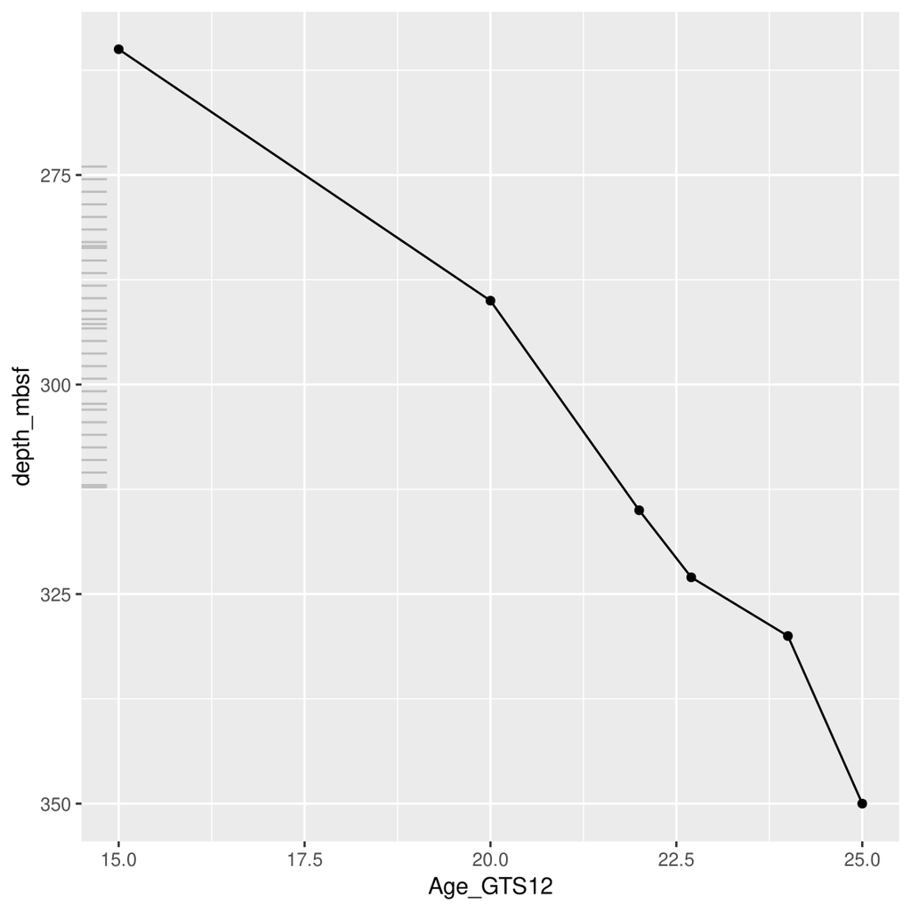

```r
## agem <- read_excel("dat/Agemodel.xlsx")
agem <- tribble( ~ depth_mbsf, ~ Age_GTS12,
                260, 15,
                290, 20,
                315, 22,
                323, 22.7,
                330, 24,
                350, 25)
agem |>
  ggplot(aes(x = Age_GTS12, y = depth_mbsf)) +
  ## geom_smooth(span = .05) +
  geom_line() +
  geom_point() +
  # annotate cores we have pics for
  geom_rug(aes(y = `Top(mbsf)`),
           colour = "grey",
           inherit.aes = FALSE,
           data = imgs) +
  scale_y_reverse()
```

Apply the agemodel. I’m assuming that the top_age and bot_age are in mbsf, because the rmcd column in the agemodel is empty!

```r
imgs <- imgs |>
  mutate(top_age = approx(x = agem$depth_mbsf, y = agem$Age_GTS12,
                          xout = `Top(mbsf)`)$y,
         bot_age = approx(x = agem$depth_mbsf, y = agem$Age_GTS12,
                      xout = `Top(mbsf)` + `LL(m)`)$y)
```

Add the age information to the colourlog

```r
newflat <- flat |>
  # tidylog is nice because it prints some messages about how the join went.
  tidylog::left_join(coresumm |>
                       mutate(Sc = ifelse(str_detect(Sc, "CC"), "8", Sc) |>
                                parse_integer()),
                     by = c('site' = 'Site',
                            'hole' = 'H',
                            'core' = 'Cor',
                            'type' = 'T',
                            'section' = 'Sc'))
```

```
# left_join: added 5 columns (Leg, LL(m), CL(m), Top(mbsf), Comment)
```

```
#            > rows only in x       0
```

```
#            > rows only in y  (1,065)
```

```
#            > matched rows       977
```

```
#            >                 =======
```

```
#            > rows total         977
```

```r
glimpse(newflat)
```

```
# Rows: 977
# Columns: 37
# $ file                                    <chr> "959A30X-1.dat", "959A30X-1.da…
# $ site                                    <dbl> 959, 959, 959, 959, 959, 959, …
# $ hole                                    <chr> "A", "A", "A", "A", "A", "A", …
# $ type                                    <chr> "X", "X", "X", "X", "X", "X", …
# $ core                                    <dbl> 30, 30, 30, 30, 30, 30, 30, 30…
# $ section                                 <int> 1, 1, 1, 1, 1, 1, 1, 1, 1, 1, …
# $ distance_from_core_top1                 <dbl> 0.5, 1.5, 2.5, 3.5, 4.5, 5.5, …
# $ mean_greyscale_values1                  <dbl> 40.01014, 39.25964, 43.37678, …
# $ standard_deviation_of_greyscale_values1 <dbl> 61.63746, 65.34229, 57.38894, …
# $ median_of_greyscale_values1             <dbl> 0.0, 0.0, 18.0, 53.0, 55.0, 48…
# $ mean_red_values1                        <dbl> 13.96197, 13.56947, 15.21095, …
# $ standard_deviation_of_red_values1       <dbl> 21.34318, 22.61043, 20.03387, …
# $ median_of_red_values1                   <dbl> 0.0, 0.0, 7.0, 20.0, 20.0, 18.…
# $ mean_green_values1                      <dbl> 13.26065, 13.05020, 13.13540, …
# $ standard_deviation_of_green_values1     <dbl> 21.00893, 22.70261, 19.46839, …
# $ median_of_green_values1                 <dbl> 0.0, 0.0, 3.0, 15.0, 15.0, 13.…
# $ mean_blue_values1                       <dbl> 12.78753, 12.63996, 15.03043, …
# $ standard_deviation_of_blue_values1      <dbl> 19.43377, 20.23959, 18.22221, …
# $ median_of_blue_values1                  <dbl> 0, 0, 8, 18, 19, 17, 22, 24, 2…
# $ distance_from_core_top2                 <dbl> 0.5, 1.5, 2.5, 3.5, 4.5, 5.5, …
# $ mean_greyscale_values2                  <dbl> 133.6398, 142.6307, 127.5649, …
# $ standard_deviation_of_greyscale_values2 <dbl> 43.45625, 58.47073, 49.49661, …
# $ median_of_greyscale_values2             <dbl> 130.0, 130.0, 114.0, 116.0, 10…
# $ mean_red_values2                        <dbl> 46.34674, 49.23542, 44.50100, …
# $ standard_deviation_of_red_values2       <dbl> 14.98561, 20.49059, 17.24443, …
# $ median_of_red_values2                   <dbl> 45.0, 45.0, 40.0, 41.0, 37.0, …
# $ mean_green_values2                      <dbl> 45.15134, 48.60043, 41.56687, …
# $ standard_deviation_of_green_values2     <dbl> 15.15645, 21.61945, 17.96692, …
# $ median_of_green_values2                 <dbl> 44, 44, 37, 37, 34, 35, 35, 33…
# $ mean_blue_values2                       <dbl> 42.14176, 44.79482, 41.49701, …
# $ standard_deviation_of_blue_values2      <dbl> 13.73924, 16.90331, 14.81062, …
# $ median_of_blue_values2                  <dbl> 41, 41, 38, 38, 34, 35, 35, 35…
# $ Leg                                     <dbl> 159, 159, 159, 159, 159, 159, …
# $ `LL(m)`                                 <dbl> 1.5, 1.5, 1.5, 1.5, 1.5, 1.5, …
# $ `CL(m)`                                 <dbl> 1.5, 1.5, 1.5, 1.5, 1.5, 1.5, …
# $ `Top(mbsf)`                             <dbl> 274, 274, 274, 274, 274, 274, …
# $ Comment                                 <chr> NA, NA, NA, NA, NA, NA, NA, NA…
```

## calculate depth

The above metadata gives us the depth of each top of the section, but our “samples” are obviously continuously spaced throughout each section.

```r
depthcalc <- newflat  %>%
  # add the section depth (in mbsf) and the top depth (in cm).
  mutate(depth = `Top(mbsf)` + distance_from_core_top2 * 0.01)

# inspect the new depth
depthcalc %>%
  select(`Top(mbsf)`, distance_from_core_top2, depth) |>
  tail()
```

```
# # A tibble: 6 × 3
#   `Top(mbsf)` distance_from_core_top2 depth
#         <dbl>                   <dbl> <dbl>
# 1        283.                    24.5  284.
# 2        283.                    25.5  284.
# 3        283.                    26.5  284.
# 4        283.                    27.5  284.
# 5        283.                    28.5  284.
# 6        283.                    29.5  284.
```

We now have our entire colourlog and the associated core depth!

## apply the agemodel

Make sure you know which column holds the age (is it in ka or in Ma?) and which one has the depth.

```r
depthcalc <- depthcalc |>
  mutate(age = approx(agem$depth_mbsf, agem$Age_GTS12,
                      xout = depth)$y)
```

# calculate colour

The colourlog output is not a colour that R knows how to plot yet, so we have to convert the separate red, green, and blue (RGB) values into a single character that defines the colour (as you may recognize from Photoshop).

```r
colourlog <- depthcalc |>
  # play around with the maxColorValue here! I think it should be 255, from memory.
  mutate(colour = rgb(mean_red_values2,
                      mean_green_values2,
                      mean_blue_values2,
                      maxColorValue = 255))
```

Create a plot to show data

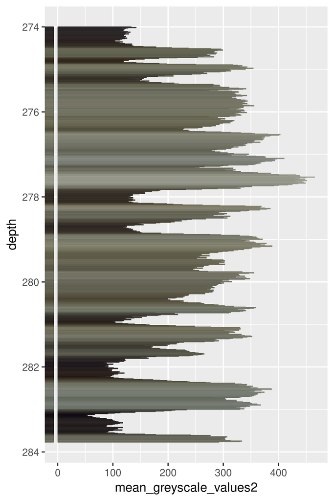

```r
colourplot <- colourlog |>
  ## arrange(depth) |>
  ggplot(aes(y = depth,
             x = mean_greyscale_values2,
             colour= colour,
             core = core, section = section)) +
  # there are many nice ways to plot this data!
  # this will just draw the familiar line
  ## geom_line(colour = "black", orientation = "y") +
  ## geom_point() +
  # this makes it easier to see
  ## geom_area(colour = "black", orientation = "y") +
  # the rug is like a cleaned-up average colour log
  geom_rug(aes(y = depth, colour = colour), sides = 'l') +
  # make the colours extend to the mean grayscale value
  # this is a bit hacky because it's drawing segments for each step
  # if you zoom in very far, you should increase the segment thickness
  geom_segment(aes(x = 0, xend = mean_greyscale_values2,
                   y = depth, yend = depth)) +
  scale_colour_identity() +
  scale_y_reverse()
colourplot
```

Save plot and data

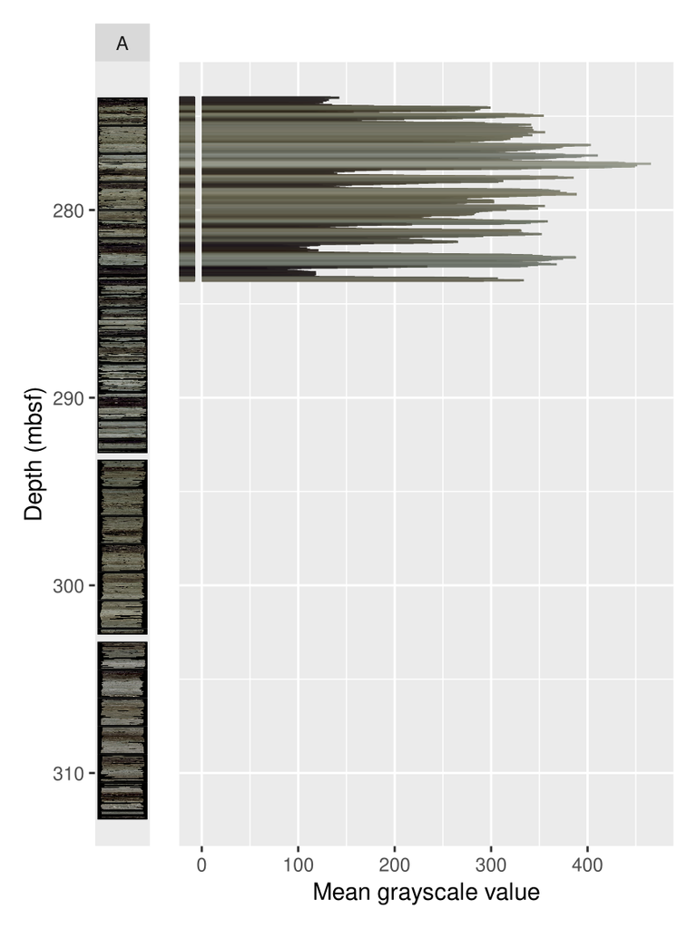

```r
# make sure that corepics and colourplot have the same depth scale
(corepics +
  coord_cartesian(ylim = c(312, 274)) +
   labs(y = "Depth (mbsf)") +
   theme(axis.title.x = element_blank(),
         axis.text.x = element_blank(),
         axis.ticks.x = element_blank(),
         panel.grid = element_blank())) +
  (colourplot +
     labs(x = "Mean grayscale value") +
     coord_cartesian(ylim = c(312, 274)) +
     # remove the axis from the right part
     theme(axis.title.y = element_blank(),
           axis.text.y = element_blank(),
           axis.ticks.y = element_blank())) +
  plot_layout(ncol = 2, widths = c(.1, .9))
```

```r
ggsave('imgs/colouranalysis.pdf', width = 10, height = 25, units = c('cm'))

write_csv(colourlog, file = "out/colourdata.csv")
```

# references

Zeeden, C., Hilgen, F., Röhl, U., Seelos, K., & Lourens, L. (2015). Sediment color as a tool in cyclostratigraphy – a new application for improved data acquisition and correction from drill cores. Newsletters on Stratigraphy, 48(3), 277–285. https://doi.org/10.1127/nos/2015/0064